# Assignment 2

Rizny Mubarak

2023-09-05

```r
# Load necessary libraries
library(forecast)
library(tsutils)
```

```r
library(ggplot2)
```

## Level A

### 1. Loading Data

```r
# Load data from csv file
Y <- read.csv("./workshop1R.csv")
# Pick the first time series for modelling
y <- Y[,1]
# Transform it into a time series
y <- ts(y,frequency=12)
```

### 2. Constructing estimation and hold-out sets

```r
y.tst <- tail(y,12)
y.trn <- head(y,48)
print(y.trn)
```

```
##        Jan      Feb      Mar      Apr      May      Jun      Jul      Aug
## 1 309.5927 285.0966 298.8200 284.3028 308.5171 306.8993 325.4628 326.9226
## 2 339.0753 334.1232 361.4546 336.1173 319.6460 317.3951 328.0461 304.5760
## 3 328.0343 322.7103 329.1623 312.8083 319.9644 310.1535 338.1874 314.8126
## 4 307.4285 347.2009 326.6501 308.4443 299.1128 341.9722 302.1470 295.1502
##        Sep      Oct      Nov      Dec
## 1 302.5102 319.5777 332.5051 342.4510
## 2 355.3091 330.1500 342.8376 327.5952
## 3 345.3493 313.4708 304.8354 311.6021
## 4 351.9557 332.8738 324.6155 306.7664
```

### 3. Exploration

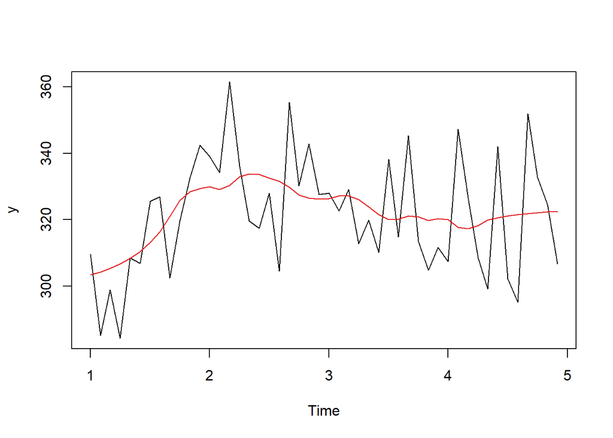

```r
cma <- cmav(y.trn,outplot=1)
```

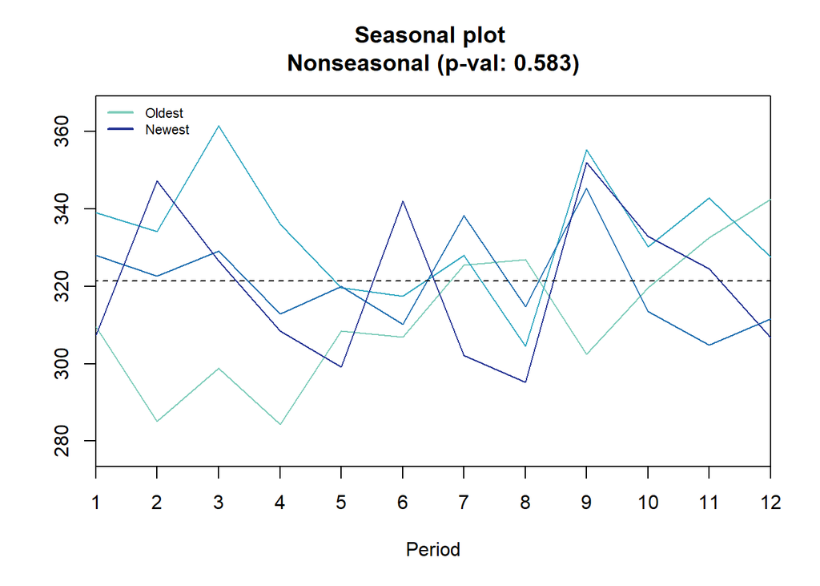

```
## Results of statistical testing
## Evidence of trend: FALSE  (pval: 0.154)
## Evidence of seasonality: FALSE  (pval: 0.583)
```

```r
seasplot(y.trn)
```

### 4. Forecasting

#### 4.1 Model fitting

```r
ets(y.trn,model="ANN")
```

```
## ETS(A,N,N)
##
## Call:
##  ets(y = y.trn, model = "ANN")
##
##   Smoothing parameters:
##     alpha = 0.2315
##
##   Initial states:
##     l = 304.1632
##
##   sigma:  17.7462
##
##      AIC     AICc      BIC
## 465.8872 466.4326 471.5008
```

```r
fit1 <- ets(y.trn,model="ANN")
print(fit1)
```

```
## ETS(A,N,N)
##
## Call:
##  ets(y = y.trn, model = "ANN")
##
##   Smoothing parameters:
##     alpha = 0.2315
##
##   Initial states:
##     l = 304.1632
##
##   sigma:  17.7462
##
##      AIC     AICc      BIC
## 465.8872 466.4326 471.5008
```

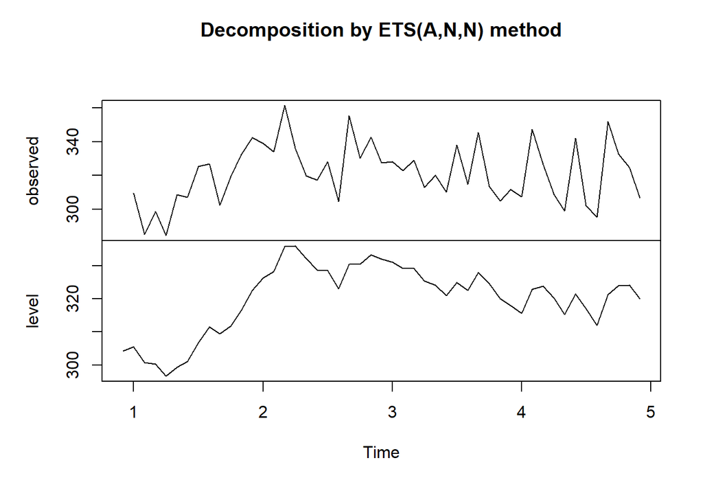

```r
plot(fit1)
```

```r
class(fit1)
```

```
## [1] "ets"
```

```r
names(fit1)
```

```
##  [1] "loglik"     "aic"        "bic"        "aicc"       "mse"
##  [6] "amse"       "fit"        "residuals"  "fitted"     "states"
## [11] "par"        "m"          "method"     "series"     "components"
## [16] "call"       "initstate"  "sigma2"     "x"
```

```r
fit1$fitted
```

```
##        Jan      Feb      Mar      Apr      May      Jun      Jul      Aug
## 1 304.1632 305.4201 300.7152 300.2764 296.5785 299.3423 301.0918 306.7338
## 2 322.5299 326.3602 328.1574 335.8658 335.9240 332.1556 328.7385 328.5782
## 3 331.9730 331.0612 329.1279 329.1359 325.3560 324.1078 320.8773 324.8847
## 4 318.0192 315.5674 322.8906 323.7610 320.2151 315.3298 321.4977 317.0179
##        Sep      Oct      Nov      Dec
## 1 311.4076 309.3478 311.7161 316.5288
## 2 323.0216 330.4963 330.4161 333.2917
## 3 322.5529 327.8304 324.5061 319.9523
## 4 311.9554 321.2157 323.9146 324.0768
```

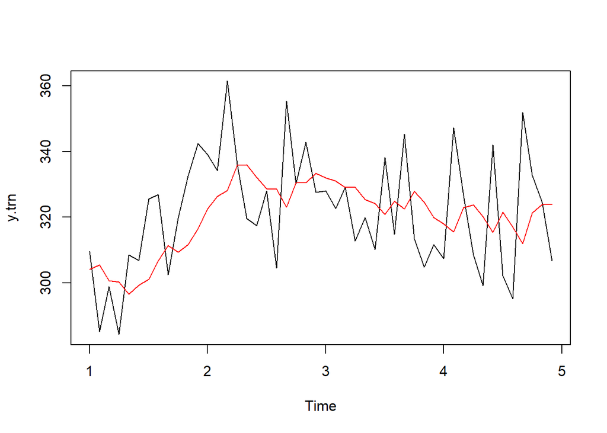

```r
plot(y.trn)
lines(fit1$fitted, col="red")
```

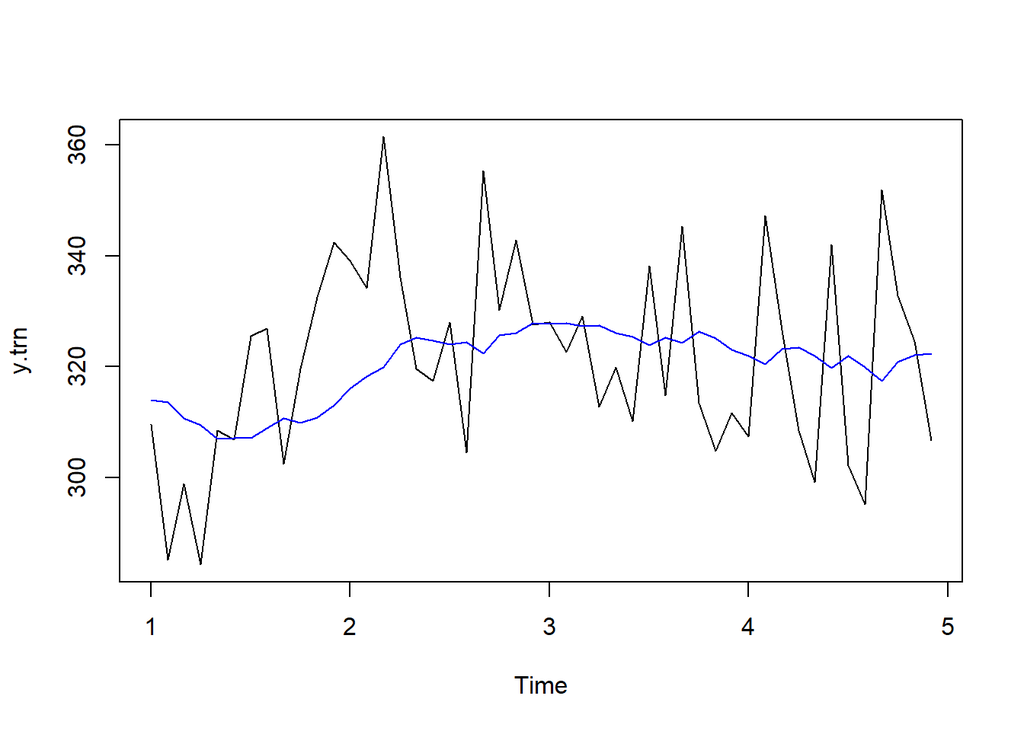

```r
fit2 <- ets(y.trn, model = "ANN", alpha = 0.1)
plot(y.trn)
lines(fit2$fitted,col="blue")
```

```r
fit1$mse
```

```
## [1] 301.8053
```

```r
fit2$mse
```

```
## [1] 313.4249
```

#### 4.2 Forecasting

```r
frc1 <- forecast(fit1, h=12)
print(frc1)
```

```
##       Point Forecast    Lo 80    Hi 80    Lo 95    Hi 95
## Jan 5       320.0694 297.3267 342.8121 285.2875 354.8513
## Feb 5       320.0694 296.7253 343.4135 284.3676 355.7712
## Mar 5       320.0694 296.1389 343.9999 283.4708 356.6679
## Apr 5       320.0694 295.5666 344.5722 282.5955 357.5433
## May 5       320.0694 295.0073 345.1315 281.7402 358.3986
## Jun 5       320.0694 294.4602 345.6786 280.9035 359.2353
## Jul 5       320.0694 293.9246 346.2142 280.0844 360.0544
## Aug 5       320.0694 293.3997 346.7391 279.2817 360.8571
## Sep 5       320.0694 292.8850 347.2538 278.4945 361.6443
## Oct 5       320.0694 292.3798 347.7590 277.7219 362.4169
## Nov 5       320.0694 291.8837 348.2551 276.9631 363.1757
## Dec 5       320.0694 291.3962 348.7426 276.2175 363.9213
```

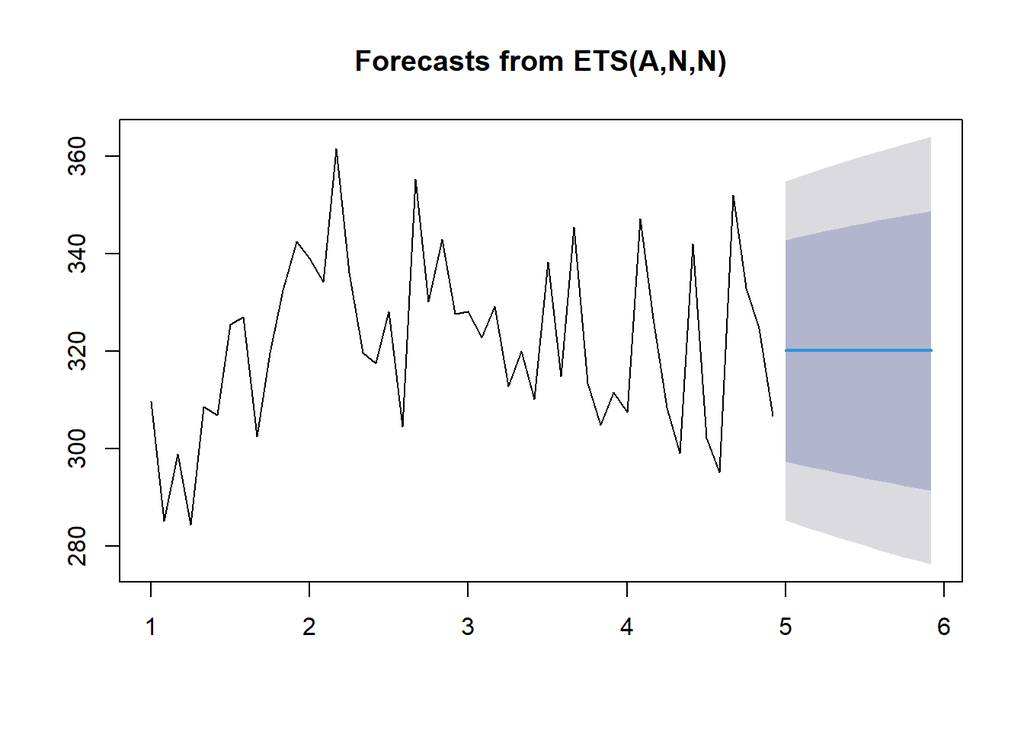

```r
plot(frc1)
```

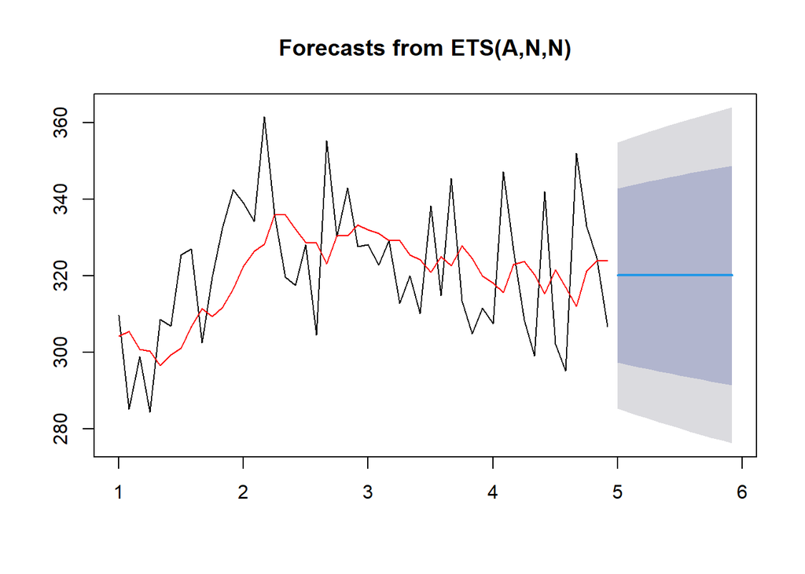

```r
plot(frc1)
lines(fit1$fitted,col="red")
```

```r
names(frc1)
```

```
##  [1] "model"     "mean"      "level"     "x"         "upper"     "lower"
##  [7] "fitted"    "method"    "series"    "residuals"
```

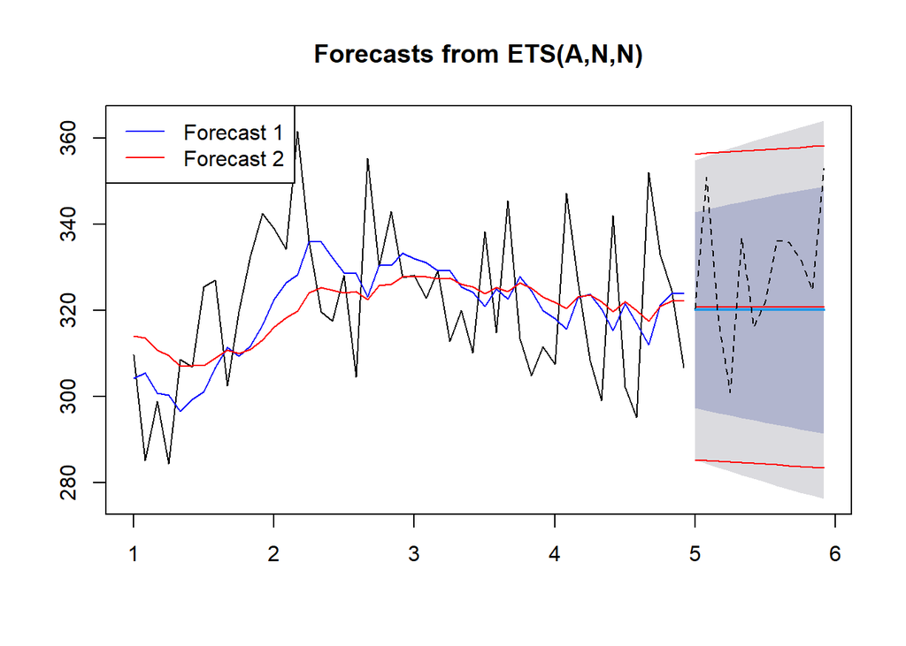

```r
frc2 <- forecast(fit2,h=12) # Store the forecasts
plot(frc1)
lines(fit1$fitted,col="blue")
lines(frc2$mean,col="red")
lines(fit2$fitted,col="red")
lines(frc2$lower[,2],col="red") # 95% lower
lines(frc2$upper[,2],col="red") # 95% upper
lines(y.tst,lty=2)
# Add legend to the plot
legend("topleft",c("Forecast 1","Forecast 2"),col=c("blue","red"),lty=1)
```

```r
MAE1 <- mean(abs(y.tst - frc1$mean))
MAE2 <- mean(abs(y.tst - frc2$mean))
MAE <- c(MAE1, MAE2)
names(MAE) <- paste0("Forecast ",1:2)
round(MAE,3)
```

```
## Forecast 1 Forecast 2
##     13.087     12.794
```

#### 4.3 Model selection

```r
fit3 <- ets(y.trn, model= "AAA", damped=TRUE)
frc3 <- forecast(fit3,h=12)
print(fit3)
```

```
## ETS(A,Ad,A)
##
## Call:
##  ets(y = y.trn, model = "AAA", damped = TRUE)
##
##   Smoothing parameters:
##     alpha = 0.0833
##     beta  = 1e-04
##     gamma = 0.0082
##     phi   = 0.8651
##
##   Initial states:
##     l = 300.0511
##     b = 4.7163
##     s = 2.9611 -0.7194 -4.9892 11.6525 -12.6768 5.3307
##            -3.0213 -16.3023 -8.3262 13.0008 10.2468 2.8432
##
##   sigma:  18.8453
##
##      AIC     AICc      BIC
## 482.7128 506.2990 516.3944
```

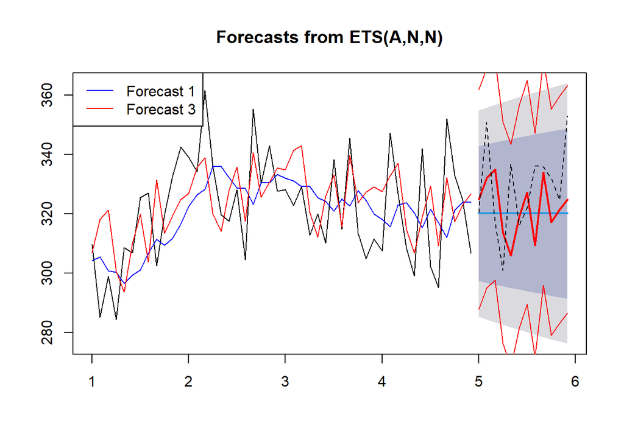

```r
plot(frc1)
lines(fit1$fitted,col="blue")
lines(frc3$mean,col="red",lwd=2) # lwd=2 makes the line thicker
lines(fit3$fitted,col="red")
lines(frc3$upper[,2],col="red")
lines(frc3$lower[,2],col="red")
lines(y.tst,lty=2)
legend("topleft",c("Forecast 1","Forecast 3"),col=c("blue","red"),lty=1)
```

```r
MAE3 <- mean(abs(y.tst - frc3$mean))
round(MAE3,3)
```

```
## [1] 13.99
```

```r
round(MAE,3)
```

```
## Forecast 1 Forecast 2
##     13.087     12.794
```

```r
MSE1 <- mean((y.tst - frc1$mean)^2)
MSE2 <- mean((y.tst - frc2$mean)^2)
MSE3 <- mean((y.tst - frc3$mean)^2)
MSE <- c(MSE1, MSE2, MSE3)
RMSE <- sqrt(MSE)
names(RMSE) <- paste0("Forecast ",1:3)
round(RMSE,3)
```

```
## Forecast 1 Forecast 2 Forecast 3
##     16.770     16.399     17.306
```

```r
crit <- array(NA,c(3,3))
print(crit)
```

```
##      [,1] [,2] [,3]
## [1,]   NA   NA   NA
## [2,]   NA   NA   NA
## [3,]   NA   NA   NA
```

```r
crit <- array(NA,c(3,3),dimnames=list(c("Forecast 1", "Forecast 2", "Forecast 3"),
c("AIC","AICc","BIC"))) # I can split lines!
print(crit)
```

```
##            AIC AICc BIC
## Forecast 1  NA   NA  NA
## Forecast 2  NA   NA  NA
## Forecast 3  NA   NA  NA
```

```r
models <- list(fit1, fit2, fit3)

for (i in 1:3) {
  crit[i, "AIC"] <- models[[i]]$aic
  crit[i, "AICc"] <- models[[i]]$aicc
  crit[i, "BIC"] <- models[[i]]$bic
}

print(crit)
```

```
##                 AIC     AICc      BIC
## Forecast 1 465.8872 466.4326 471.5008
## Forecast 2 465.7005 465.9672 469.4429
## Forecast 3 482.7128 506.2990 516.3944
```

```r
fit4 <- ets(y.trn)
print(fit4)
```

```
## ETS(A,N,N)
##
## Call:
##  ets(y = y.trn)
##
##   Smoothing parameters:
##     alpha = 0.2315
##
##   Initial states:
##     l = 304.1632
##
##   sigma:  17.7462
##
##      AIC     AICc      BIC
## 465.8872 466.4326 471.5008
```

# Exercise

“To enhance both conciseness and clarity within this report, the subsequent sections will adopt the following terminology conventions in the forthcoming code:

1. “fit” will be employed when specifying an ANN model with automatic alpha selection.

2. “fit_m1”, “fit_m2” will be utilized when denoting an ANN model with an explicitly specified alpha value.

Moreover, these identical nomenclature conventions will be consistently applied to the forecasting variable, which will uniformly be denoted as “frc” in all relevant code sections.”

## Level B

### 1. Loading Data

```r
y <- Y[,2]
# Transform it into a time series
y <- ts(y,frequency=12)
```

### 2. Constructing estimation and hold-out sets

```r
y.tst <- tail(y,12)
y.trn <- head(y,48)
```

### 3. Exploration

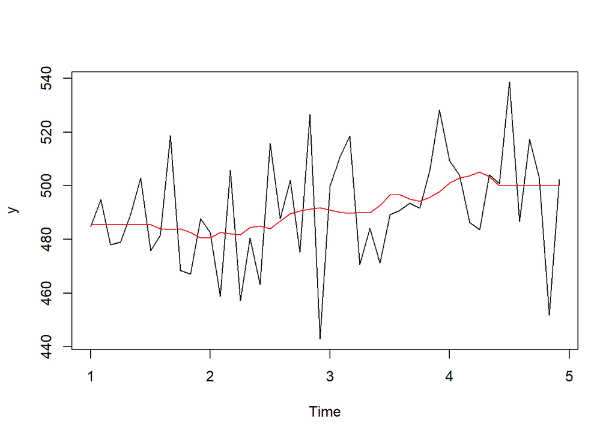

```r
cma <- cmav(y.trn,outplot=1)
```

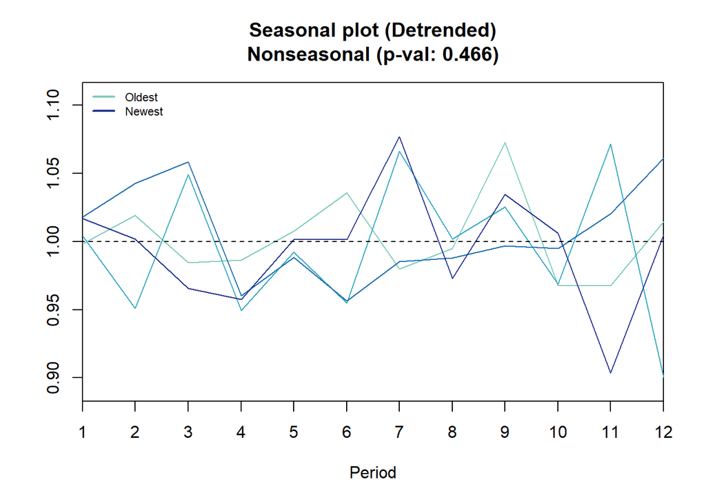

```
## Results of statistical testing
## Evidence of trend: TRUE  (pval: 0)
## Evidence of seasonality: FALSE  (pval: 0.466)
```

```r
seasplot(y.trn)
```

### 4. Forecasting

#### 4.1 Model fitting

```r
# Automatic Alpha ANN
fit <- ets(y.trn,model="ANN")
print(fit)
```

```
## ETS(A,N,N)
##
## Call:
##  ets(y = y.trn, model = "ANN")
##
##   Smoothing parameters:
##     alpha = 0.0541
##
##   Initial states:
##     l = 487.8891
##
##   sigma:  20.9366
##
##      AIC     AICc      BIC
## 481.7588 482.3043 487.3724
```

```r
# Alpha ANN
fit_m1 <- ets(y.trn,model="ANN", alpha = 0.08 )
print(fit)
```

```
## ETS(A,N,N)
##
## Call:
##  ets(y = y.trn, model = "ANN")
##
##   Smoothing parameters:
##     alpha = 0.0541
##
##   Initial states:
##     l = 487.8891
##
##   sigma:  20.9366
##
##      AIC     AICc      BIC
## 481.7588 482.3043 487.3724
```

```r
# Alpha M2 ANN
fit_m2 <- ets(y.trn,model="ANN", alpha = 0.02 )
print(fit_m2)
```

```
## ETS(A,N,N)
##
## Call:
##  ets(y = y.trn, model = "ANN", alpha = 0.02)
##
##   Smoothing parameters:
##     alpha = 0.02
##
##   Initial states:
##     l = 490.3465
##
##   sigma:  20.9358
##
##      AIC     AICc      BIC
## 479.7548 480.0215 483.4972
```

```r
cirt <- array(NA, c(3, 4), dimnames = list(c("Automatic", "M1", "M2"),
                                         c("MSE", "AIC", "AICc","BIC")))

models <- list(fit, fit_m1, fit_m2)

for (i in 1:3) {
  cirt[i, "MSE"] <- models[[i]]$mse
  cirt[i, "AIC"] <- models[[i]]$aic
  cirt[i, "AICc"] <- models[[i]]$aicc
  cirt[i, "BIC"] <- models[[i]]$bic
}

print(cirt)
```

```
##                MSE      AIC     AICc      BIC
## Automatic 420.0784 481.7588 482.3043 487.3724
## M1        421.3674 479.9059 480.1726 483.6483
## M2        420.0430 479.7548 480.0215 483.4972
```

#### 4.2 Forecasting

- Forecast ANN

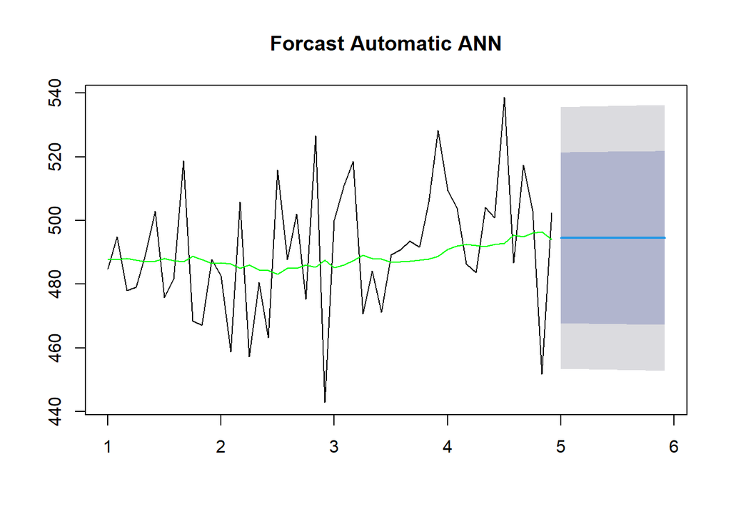

```r
# ploting Automatic ANN
frc <- forecast(fit, h=12)
plot(frc, main = "Forcast Automatic ANN")
lines(fit$fitted,col="green")
```

- Forecast ANN and Alpha M1

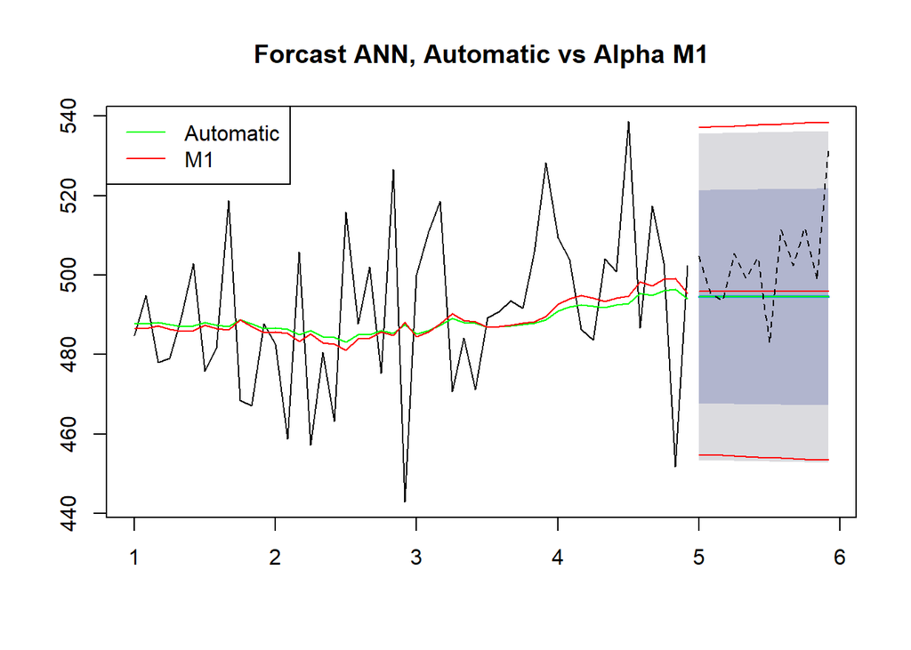

```r
# ploting M1 vs ANN
frc_m1 <- forecast(fit_m1,h=12)
plot(frc, main = "Forcast ANN, Automatic vs Alpha M1")
lines(frc$mean,col="green")
lines(fit$fitted,col="green")
lines(fit_m1$fitted,col="red")

lines(frc_m1$mean,col="red")
lines(frc_m1$lower[,2],col="red") # 95% lower
lines(frc_m1$upper[,2],col="red") # 95% upper
lines(y.tst,lty=2)

# legends
legend("topleft",c("Automatic","M1"),col=c("green","red"),lty=1)
```

- Forecast ANN and Alpha M2

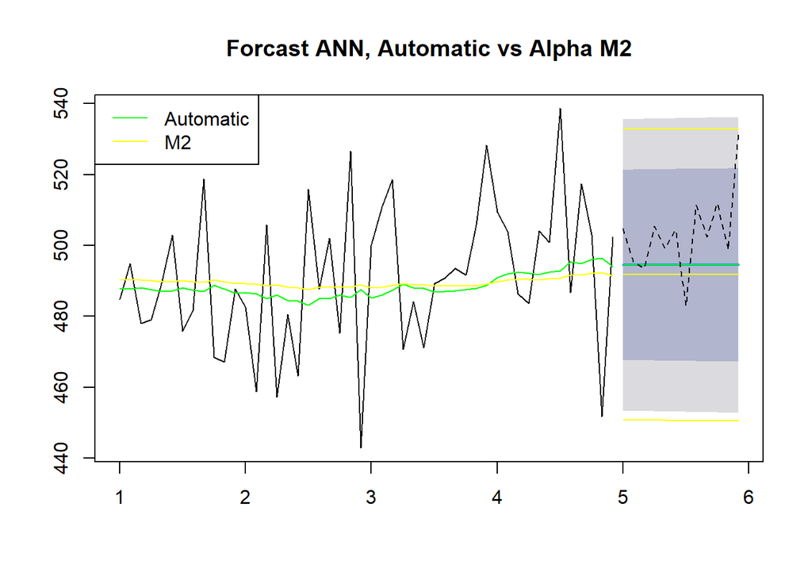

```r
# Ploting M2 vs ANN
frc_m2 <- forecast(fit_m2,h=12)
plot(frc, main = "Forcast ANN, Automatic vs Alpha M2")
lines(frc$mean,col="green")
lines(fit$fitted,col="green")
lines(fit_m2$fitted,col="yellow")

lines(frc_m2$mean,col="yellow")
lines(frc_m2$lower[,2],col="yellow") # 95% lower
lines(frc_m2$upper[,2],col="yellow") # 95% upper
lines(y.tst,lty=2)

# Add legend to the plot
legend("topleft",c("Automatic","M2"),col=c("green","yellow"),lty=1)
```

- Confidence level ANN, Alpha M1 and Alpha M2

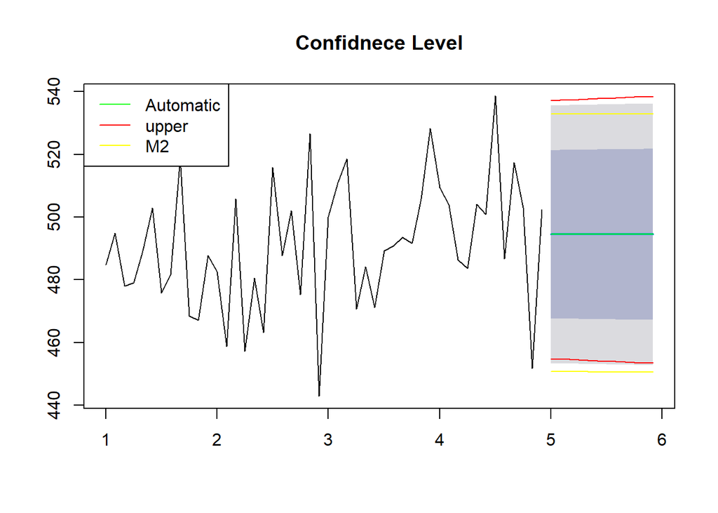

```r
# Ploting confidence level of all 3
plot(frc, main = "Confidnece Level")
lines(frc$mean,col="green")

lines(frc_m1$lower[,2],col="red") # 95% lower
lines(frc_m1$upper[,2],col="red")
lines(frc_m2$lower[,2],col="yellow") # 95% lower
lines(frc_m2$upper[,2],col="yellow") # 95% upper

# Add legend to the plot
legend("topleft",c("Automatic","upper","M2"),col=c("green","red","yellow"),lty=1)
```

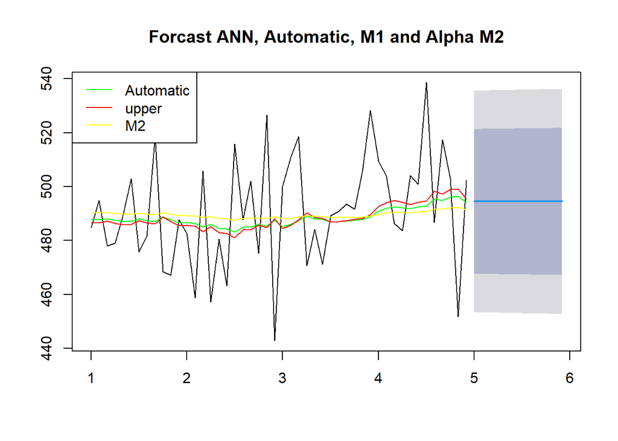

```r
plot(frc, main = "Forcast ANN, Automatic, M1 and Alpha M2")
lines(fit$fitted,col="green")
lines(fit_m1$fitted,col="red")
lines(fit_m2$fitted,col="yellow")
legend("topleft",c("Automatic","upper","M2"),col=c("green","red","yellow"),lty=1)
```

#### 4.3 Model selection

```r
# Function to calculate metrics
calculate_metrics <- function(y, frc) {
  MAE <- mean(abs(y - frc$mean))
  MSE <- mean((y - frc$mean)^2)
  RMSE <- sqrt(MSE)
  return(list(MAE = MAE, MSE = MSE, RMSE = RMSE))
}

# Calculate metrics for different forecasts
metrics_a <- calculate_metrics(y.tst, frc)
metrics_m1 <- calculate_metrics(y.tst, frc_m1)
metrics_m2 <- calculate_metrics(y.tst, frc_m2)

# Create a matrix for the metrics
metrics_matrix <- matrix(c(metrics_a$MAE, metrics_m1$MAE, metrics_m2$MAE,
                           metrics_a$RMSE, metrics_m1$RMSE, metrics_m2$RMSE,
                          metrics_a$MSE, metrics_m1$MSE, metrics_m2$MSE),
                          ncol = 3, byrow = TRUE)

# Add row and column names
rownames(metrics_matrix) <- c("MAE", "MSE", "RMSE")
colnames(metrics_matrix) <- c("Automatic", "Alpha M1", "Alpha M2")

# Display the metrics matrix
metrics_matrix
```

```
##      Automatic  Alpha M1  Alpha M2
## MAE   11.05761  10.17653  13.19261
## MSE   14.53394  13.67233  16.37449
## RMSE 211.23547 186.93268 268.12393
```

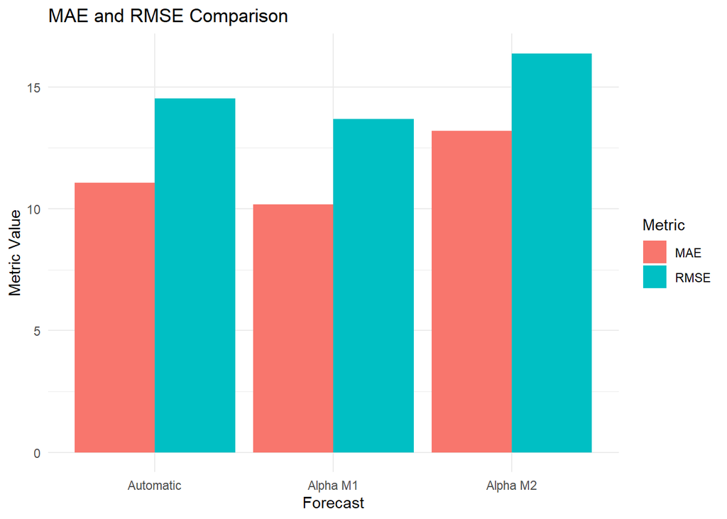

```r
# Create a data frame from the metrics matrix, excluding MSE
metrics_df <- data.frame(
  Metric = rep(c("MAE", "RMSE"), each = 3),
  Value = c(metrics_a$MAE, metrics_m1$MAE, metrics_m2$MAE,
            metrics_a$RMSE, metrics_m1$RMSE, metrics_m2$RMSE),
  Forecast = rep(c("Automatic", "Alpha M1", "Alpha M2"), times = 2)
)
metrics_df$Forecast <- factor(metrics_df$Forecast, levels = c("Automatic", "Alpha M1", "Alpha M2"))

# Create a bar plot
ggplot(metrics_df, aes(x = Forecast, y = Value, fill = Metric)) +
  geom_bar(stat = "identity", position = position_dodge()) +
  labs(title = "MAE and RMSE Comparison",
       y = "Metric Value") +
  theme_minimal()
```

### 5. Answers

- Which one is best using your judgement?

  Based on an evaluation of the in-sample data, it is observed that the **Automatic** model has performed commendably. This model effectively filters out noise and outliers, resulting in a smoother representation of the underlying level. Conversely, the M2 model, while smoothing out a significant amount of noise and outliers, may not fully capture the nuances of the level. The upper model, although not consistently following the level, provides an alternative perspective
- Which one is best using errors?

  In terms of error metrics such as AIC, MSE, RMSE, and others, it is notable that the **M2** model yields the lowest errors. Despite its occasional deviations from the level, its overall predictive accuracy, as indicated by the error metrics, is superior to the other models.
- Does the selected model perform best in the out-of-sample data?

  Contrary to the in-sample results, the out-of-sample data analysis reveals that the selected model may not be the optimal choice. In this context, the **M1**model demonstrates superior performance, as it yields the lowest RMSE and MAE values. This suggests that the upper model might generalize better to unseen data points, capturing the underlying patterns more effectively.

## LevelShift

### 1. Loading Data

```r
y <- Y[,3]
# Transform it into a time series
y <- ts(y,frequency=12)
```

### 2. Constructing estimation and hold-out sets

```r
y.tst <- tail(y,12)
y.trn <- head(y,48)
```

### 3. Exploration

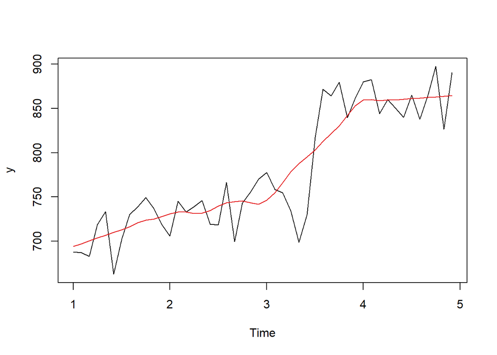

```r
cma <- cmav(y.trn,outplot=1)
```

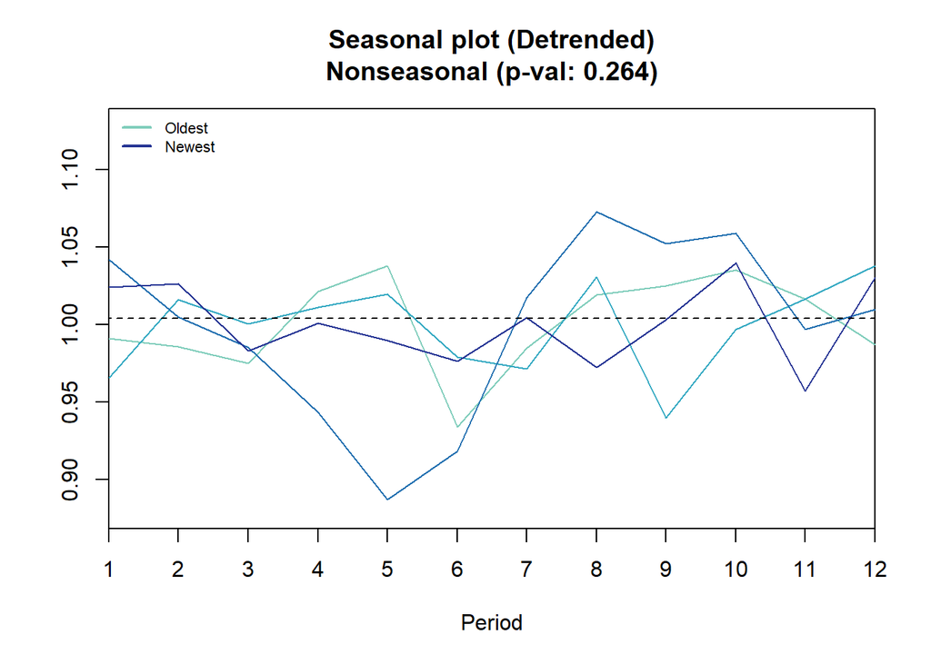

```
## Results of statistical testing
## Evidence of trend: TRUE  (pval: 0)
## Evidence of seasonality: FALSE  (pval: 0.264)
```

```r
seasplot(y.trn)
```

### 4. Forecasting

#### 4.1 Model fitting

```r
# Automatic Alpha ANN
fit <- ets(y.trn,model="ANN")
print(fit)
```

```
## ETS(A,N,N)
##
## Call:
##  ets(y = y.trn, model = "ANN")
##
##   Smoothing parameters:
##     alpha = 0.6886
##
##   Initial states:
##     l = 688.4287
##
##   sigma:  32.3896
##
##      AIC     AICc      BIC
## 523.6472 524.1926 529.2608
```

```r
# Alpha M1 ANN
fit_m1 <- ets(y.trn,model="ANN", alpha = 0.8 )
print(fit_m1)
```

```
## ETS(A,N,N)
##
## Call:
##  ets(y = y.trn, model = "ANN", alpha = 0.8)
##
##   Smoothing parameters:
##     alpha = 0.8
##
##   Initial states:
##     l = 687.9913
##
##   sigma:  32.5357
##
##      AIC     AICc      BIC
## 522.0791 522.3458 525.8215
```

```r
# Alpha M2 ANN
fit_m2 <- ets(y.trn,model="ANN", alpha = 0.4 )
print(fit_m2)
```

```
## ETS(A,N,N)
##
## Call:
##  ets(y = y.trn, model = "ANN", alpha = 0.4)
##
##   Smoothing parameters:
##     alpha = 0.4
##
##   Initial states:
##     l = 692.7714
##
##   sigma:  33.6499
##
##      AIC     AICc      BIC
## 525.3118 525.5784 529.0542
```

```r
cirt <- array(NA, c(3, 4), dimnames = list(c("Automatic", "M1", "M2"),
                                         c("MSE", "AIC", "AICc","BIC")))

models <- list(fit, fit_m1, fit_m2)

for (i in 1:3) {
  cirt[i, "MSE"] <- models[[i]]$mse
  cirt[i, "AIC"] <- models[[i]]$aic
  cirt[i, "AICc"] <- models[[i]]$aicc
  cirt[i, "BIC"] <- models[[i]]$bic
}

print(cirt)
```

```
##                MSE      AIC     AICc      BIC
## Automatic 1005.374 523.6472 524.1926 529.2608
## M1        1014.462 522.0791 522.3458 525.8215
## M2        1085.136 525.3118 525.5784 529.0542
```

#### 4.2 Forecasting

- Forecast ANN

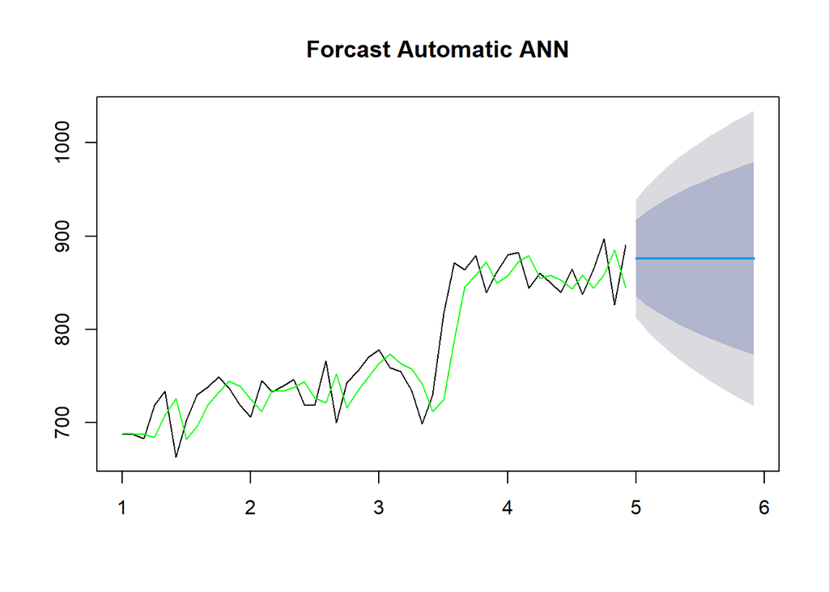

```r
# ploting Automatic ANN
frc <- forecast(fit, h=12)
plot(frc, main = "Forcast Automatic ANN")
lines(fit$fitted,col="green")
```

- Forecast ANN and Alpha M1

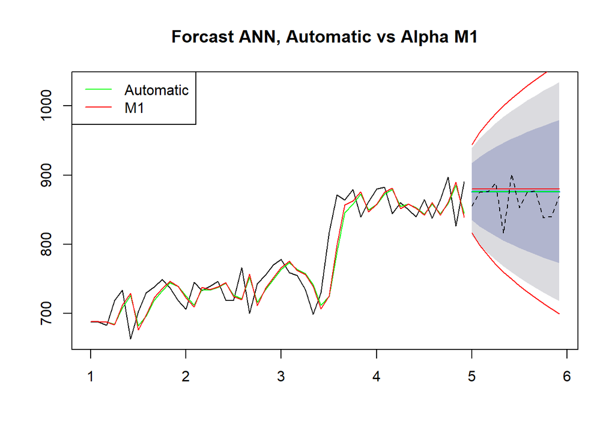

```r
# ploting M1 vs ANN
frc_m1 <- forecast(fit_m1,h=12)
plot(frc, main = "Forcast ANN, Automatic vs Alpha M1")
lines(frc$mean,col="green")
lines(fit$fitted,col="green")
lines(fit_m1$fitted,col="red")

lines(frc_m1$mean,col="red")
lines(frc_m1$lower[,2],col="red") # 95% lower
lines(frc_m1$upper[,2],col="red") # 95% upper
lines(y.tst,lty=2)

# legends
legend("topleft",c("Automatic","M1"),col=c("green","red"),lty=1)
```

- Forecast ANN and Alpha M2

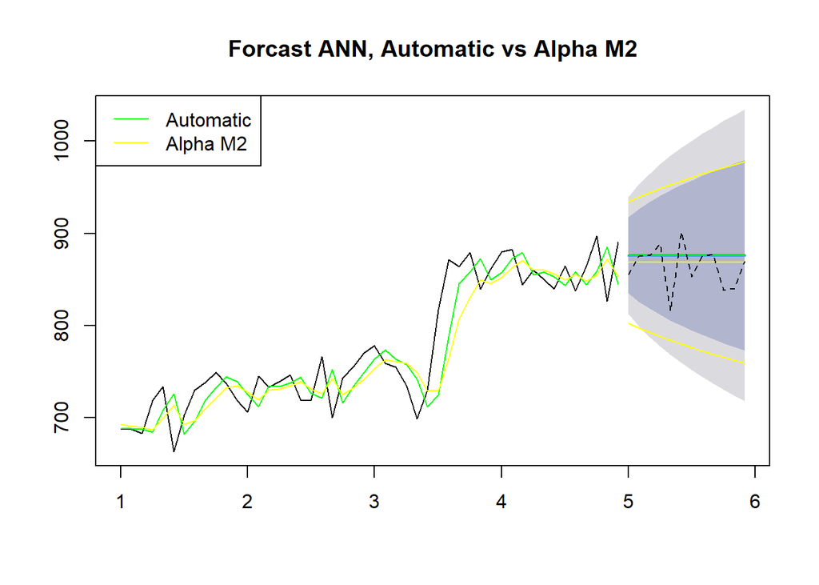

```r
# Ploting M2 vs ANN
frc_m2 <- forecast(fit_m2,h=12)
plot(frc, main = "Forcast ANN, Automatic vs Alpha M2")
lines(frc$mean,col="green")
lines(fit$fitted,col="green")
lines(fit_m2$fitted,col="yellow")

lines(frc_m2$mean,col="yellow")
lines(frc_m2$lower[,2],col="yellow") # 95% lower
lines(frc_m2$upper[,2],col="yellow") # 95% upper
lines(y.tst,lty=2)

# Add legend to the plot
legend("topleft",c("Automatic","Alpha M2"),col=c("green","yellow"),lty=1)
```

- Confidence level ANN, Alpha M1 and Alpha M2

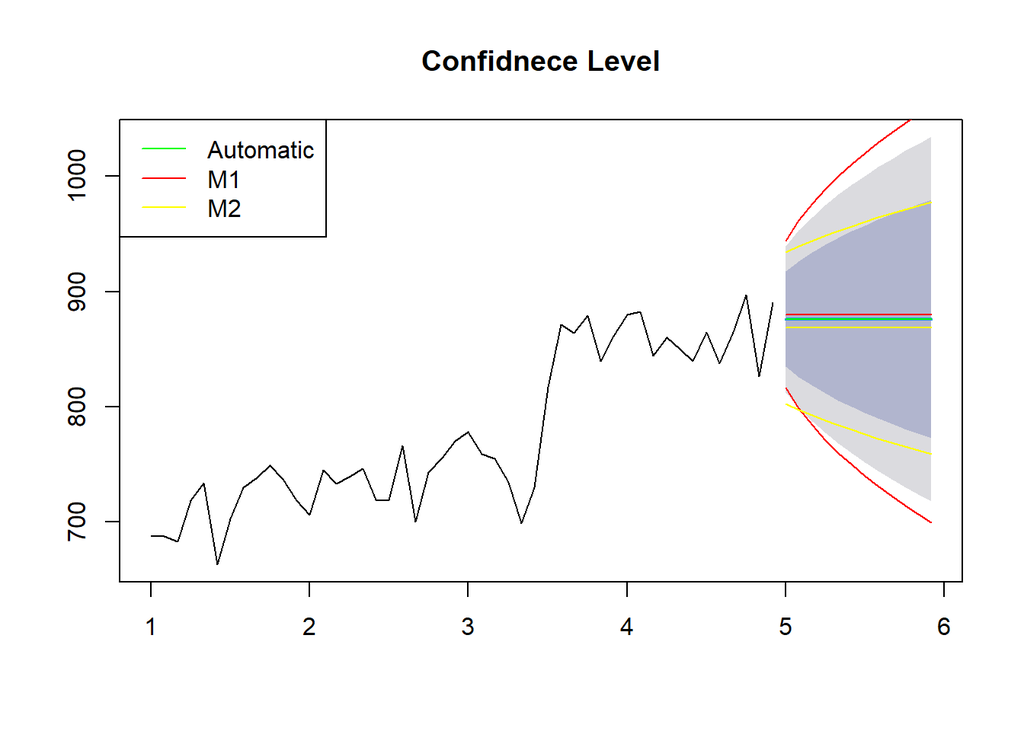

```r
# Ploting confidence level of all 3
plot(frc, main = "Confidnece Level")
lines(frc$mean,col="green")

lines(frc_m1$mean,col="red")
lines(frc_m1$lower[,2],col="red") # 95% lower
lines(frc_m1$upper[,2],col="red")

lines(frc_m2$mean,col="yellow")
lines(frc_m2$lower[,2],col="yellow") # 95% lower
lines(frc_m2$upper[,2],col="yellow") # 95% upper

# Add legend to the plot
legend("topleft",c("Automatic","M1","M2"),col=c("green","red","yellow"),lty=1)
```

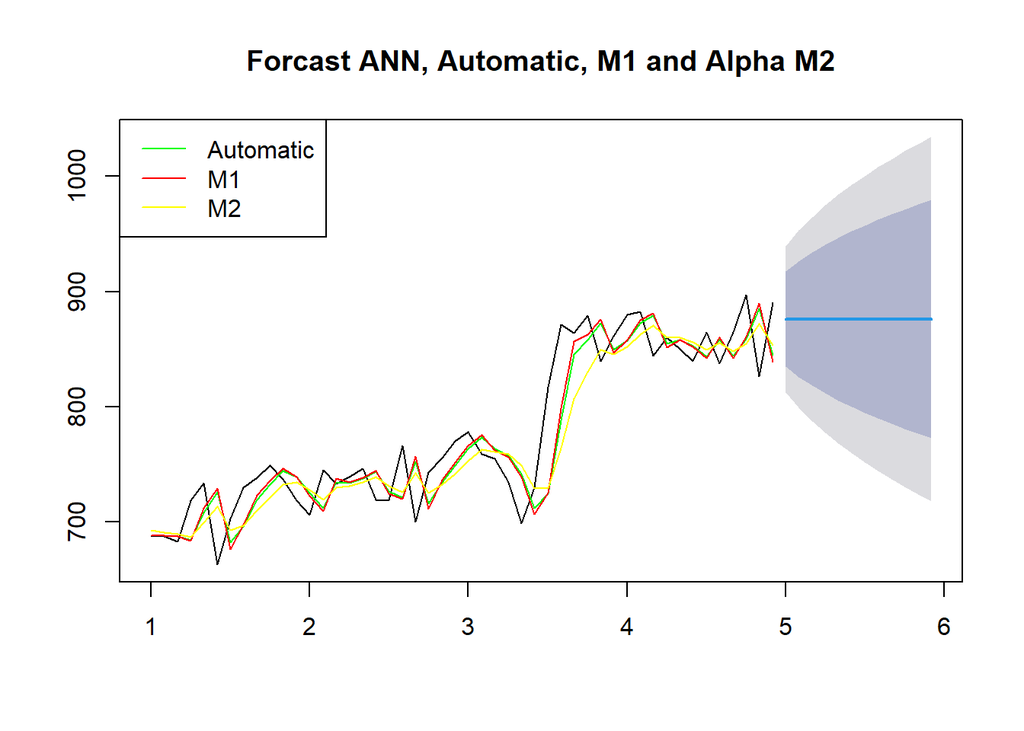

```r
plot(frc, main = "Forcast ANN, Automatic, M1 and Alpha M2")
lines(fit$fitted,col="green")
lines(fit_m1$fitted,col="red")
lines(fit_m2$fitted,col="yellow")
legend("topleft",c("Automatic","M1","M2"),col=c("green","red","yellow"),lty=1)
```

#### 4.3 Model selection

```r
# Function to calculate metrics
calculate_metrics <- function(y, frc) {
  MAE <- mean(abs(y - frc$mean))
  MSE <- mean((y - frc$mean)^2)
  RMSE <- sqrt(MSE)
  return(list(MAE = MAE, MSE = MSE, RMSE = RMSE))
}

# Calculate metrics for different forecasts
metrics_a <- calculate_metrics(y.tst, frc)
metrics_m1 <- calculate_metrics(y.tst, frc_m1)
metrics_m2 <- calculate_metrics(y.tst, frc_m2)

# Create a matrix for the metrics
metrics_matrix <- matrix(c(metrics_a$MAE, metrics_m1$MAE, metrics_m2$MAE,
                           metrics_a$RMSE, metrics_m1$RMSE, metrics_m2$RMSE,
                          metrics_a$MSE, metrics_m1$MSE, metrics_m2$MSE),
                          ncol = 3, byrow = TRUE)

# Add row and column names
rownames(metrics_matrix) <- c("MAE", "MSE", "RMSE")
colnames(metrics_matrix) <- c("Automatic", "Alpha M1", "Alpha M2")

# Display the metrics matrix
metrics_matrix
```

```
##      Automatic  Alpha M1  Alpha M2
## MAE   18.87846  21.36188  18.66568
## MSE   26.19250  28.27705  23.53792
## RMSE 686.04709 799.59154 554.03354
```

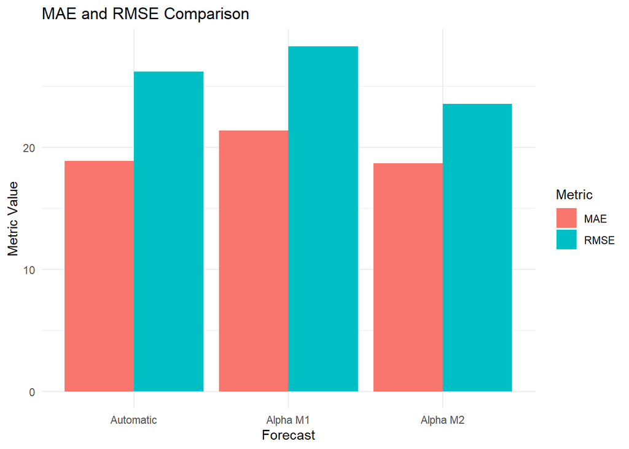

```r
# Create a data frame from the metrics matrix, excluding MSE
metrics_df <- data.frame(
  Metric = rep(c("MAE", "RMSE"), each = 3),
  Value = c(metrics_a$MAE, metrics_m1$MAE, metrics_m2$MAE,
            metrics_a$RMSE, metrics_m1$RMSE, metrics_m2$RMSE),
  Forecast = rep(c("Automatic", "Alpha M1", "Alpha M2"), times = 2)
)
metrics_df$Forecast <- factor(metrics_df$Forecast, levels = c("Automatic", "Alpha M1", "Alpha M2"))

# Create a bar plot
ggplot(metrics_df, aes(x = Forecast, y = Value, fill = Metric)) +
  geom_bar(stat = "identity", position = position_dodge()) +
  labs(title = "MAE and RMSE Comparison",
       y = "Metric Value") +
  theme_minimal()
```

### 5. Answers

- Which one is best using your judgement?

## Trend A

### 1. Loading Data

```r
y <- Y[,4]
# Transform it into a time series
y <- ts(y,frequency=12)
```

### 2. Constructing estimation and hold-out sets

```r
y.tst <- tail(y,12)
y.trn <- head(y,48)
```

### 3. Exploration

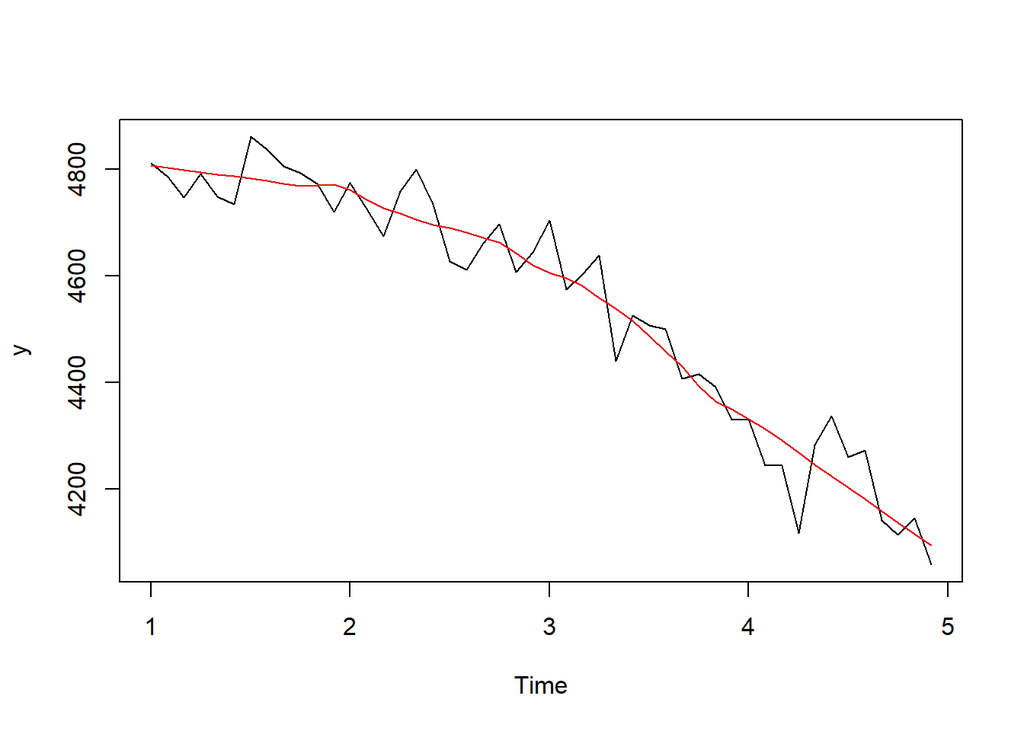

```r
cma <- cmav(y.trn,outplot=1)
```

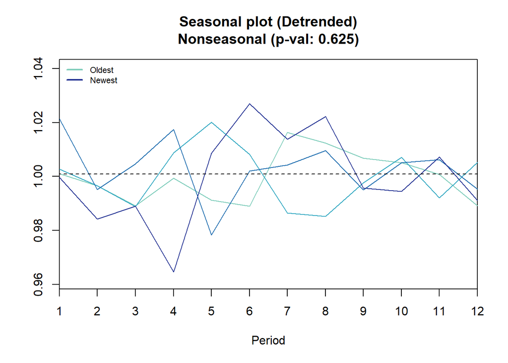

```
## Results of statistical testing
## Evidence of trend: TRUE  (pval: 0)
## Evidence of seasonality: FALSE  (pval: 0.625)
```

```r
seasplot(y.trn)
```

### 4. Forecasting

#### 4.1 Model fitting

```r
# Automatic Alpha ANN
fit <- ets(y.trn,model="ANN")
print(fit)
```

```
## ETS(A,N,N)
##
## Call:
##  ets(y = y.trn, model = "ANN")
##
##   Smoothing parameters:
##     alpha = 0.6774
##
##   Initial states:
##     l = 4800.0578
##
##   sigma:  69.4928
##
##      AIC     AICc      BIC
## 596.9323 597.4777 602.5459
```

```r
# Alpha M1 ANN
fit_m1 <- ets(y.trn,model="ANN", alpha = 0.7 )
print(fit_m1)
```

```
## ETS(A,N,N)
##
## Call:
##  ets(y = y.trn, model = "ANN", alpha = 0.7)
##
##   Smoothing parameters:
##     alpha = 0.7
##
##   Initial states:
##     l = 4800.9086
##
##   sigma:  69.5128
##
##      AIC     AICc      BIC
## 594.9598 595.2265 598.7022
```

```r
# Alpha M2 ANN
fit_m2 <- ets(y.trn,model="ANN", alpha = 0.4 )
print(fit_m2)
```

```
## ETS(A,N,N)
##
## Call:
##  ets(y = y.trn, model = "ANN", alpha = 0.4)
##
##   Smoothing parameters:
##     alpha = 0.4
##
##   Initial states:
##     l = 4788.9771
##
##   sigma:  74.2098
##
##      AIC     AICc      BIC
## 601.2368 601.5035 604.9792
```

```r
cirt <- array(NA, c(3, 4), dimnames = list(c("Automatic", "M1", "M2"),
                                         c("MSE", "AIC", "AICc","BIC")))

models <- list(fit, fit_m1, fit_m2)

for (i in 1:3) {
  cirt[i, "MSE"] <- models[[i]]$mse
  cirt[i, "AIC"] <- models[[i]]$aic
  cirt[i, "AICc"] <- models[[i]]$aicc
  cirt[i, "BIC"] <- models[[i]]$bic
}

print(cirt)
```

```
##                MSE      AIC     AICc      BIC
## Automatic 4628.035 596.9323 597.4777 602.5459
## M1        4630.694 594.9598 595.2265 598.7022
## M2        5277.633 601.2368 601.5035 604.9792
```

#### 4.2 Forecasting

- Forecast ANN

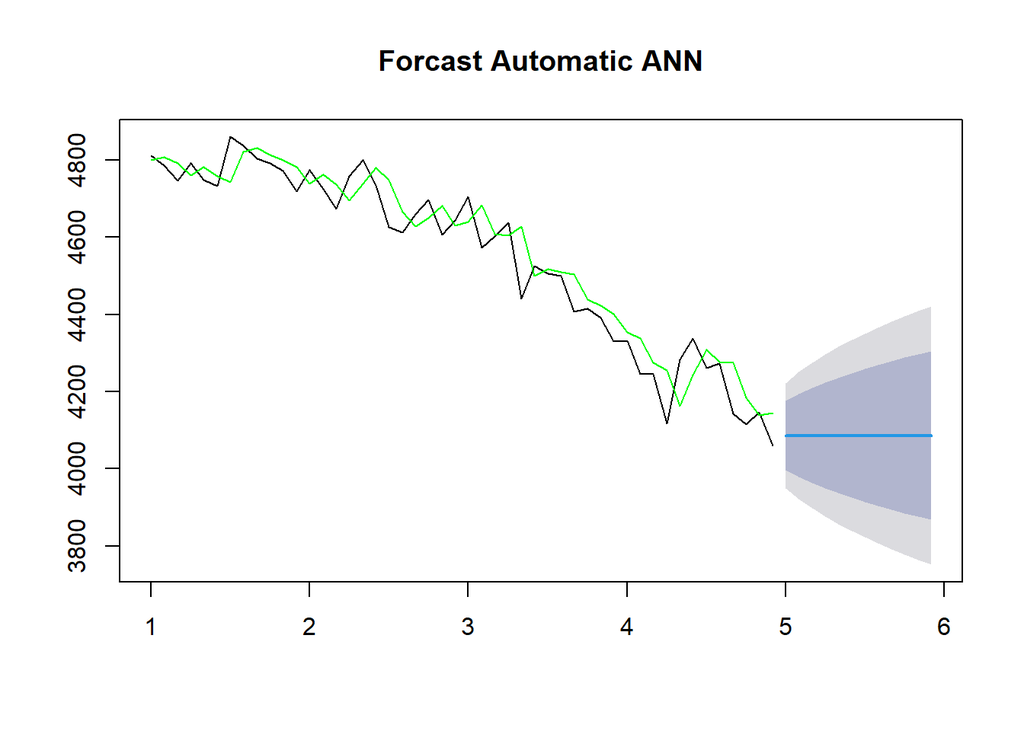

```r
# ploting Automatic ANN
frc <- forecast(fit, h=12)
plot(frc, main = "Forcast Automatic ANN")
lines(fit$fitted,col="green")
```

- Forecast ANN and Alpha M1

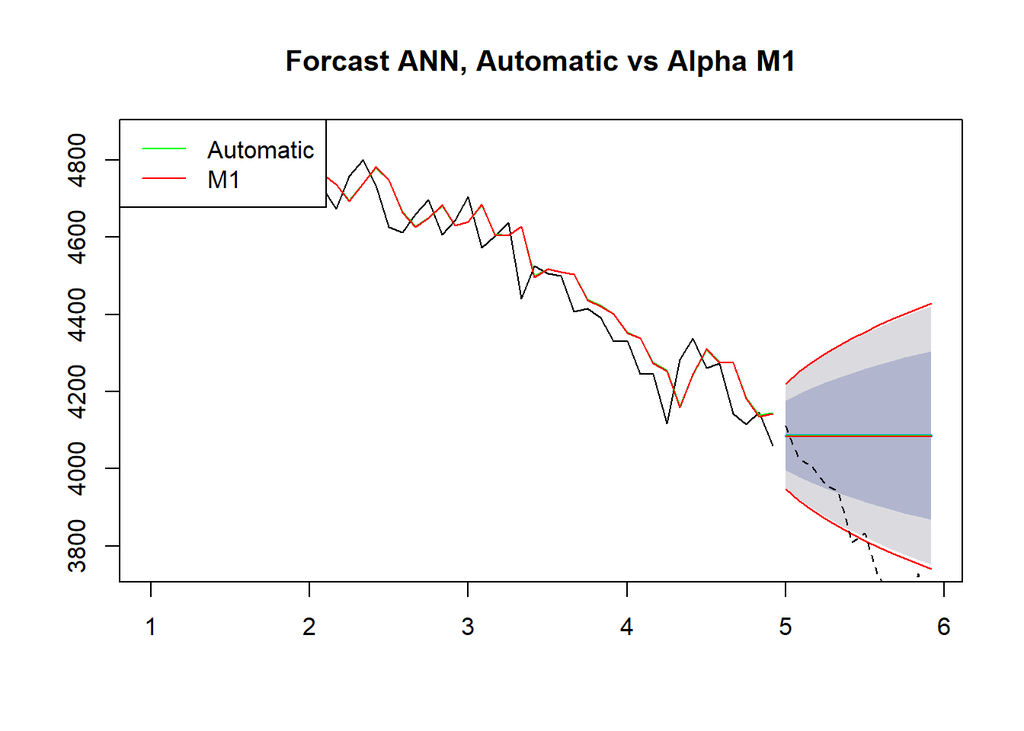

```r
# ploting M1 vs ANN
frc_m1 <- forecast(fit_m1,h=12)
plot(frc, main = "Forcast ANN, Automatic vs Alpha M1")
lines(frc$mean,col="green")
lines(fit$fitted,col="green")
lines(fit_m1$fitted,col="red")

lines(frc_m1$mean,col="red")
lines(frc_m1$lower[,2],col="red") # 95% lower
lines(frc_m1$upper[,2],col="red") # 95% upper
lines(y.tst,lty=2)

# legends
legend("topleft",c("Automatic","M1"),col=c("green","red"),lty=1)
```

- Forecast ANN and Alpha M2

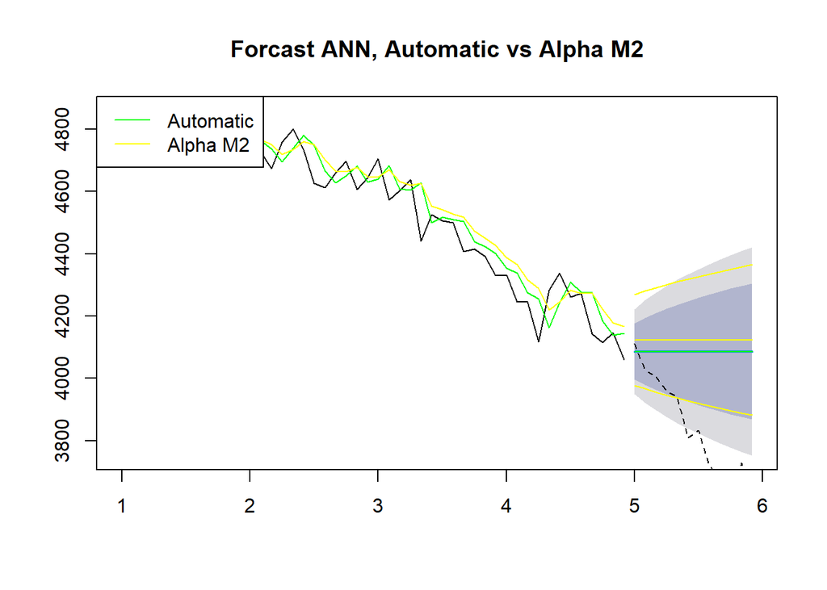

```r
# Ploting M2 vs ANN
frc_m2 <- forecast(fit_m2,h=12)
plot(frc, main = "Forcast ANN, Automatic vs Alpha M2")
lines(frc$mean,col="green")
lines(fit$fitted,col="green")
lines(fit_m2$fitted,col="yellow")

lines(frc_m2$mean,col="yellow")
lines(frc_m2$lower[,2],col="yellow") # 95% lower
lines(frc_m2$upper[,2],col="yellow") # 95% upper
lines(y.tst,lty=2)

# Add legend to the plot
legend("topleft",c("Automatic","Alpha M2"),col=c("green","yellow"),lty=1)
```

- Confidence level ANN, Alpha M1 and Alpha M2

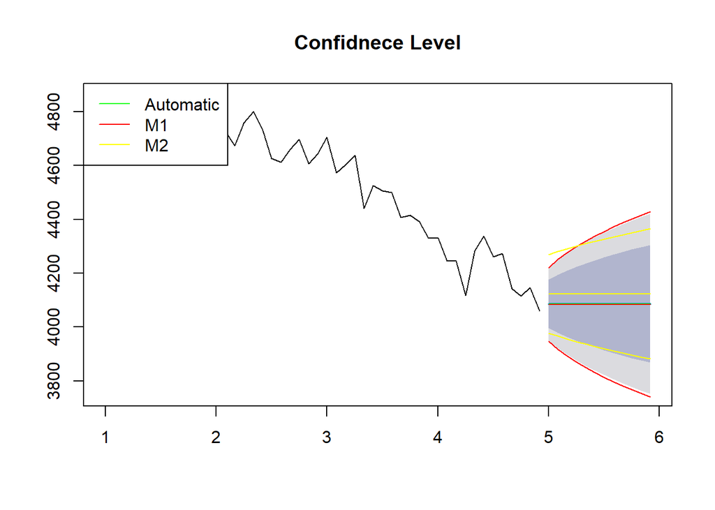

```r
# Ploting confidence level of all 3
plot(frc, main = "Confidnece Level")
lines(frc$mean,col="green")

lines(frc_m1$mean,col="red")
lines(frc_m1$lower[,2],col="red") # 95% lower
lines(frc_m1$upper[,2],col="red")

lines(frc_m2$mean,col="yellow")
lines(frc_m2$lower[,2],col="yellow") # 95% lower
lines(frc_m2$upper[,2],col="yellow") # 95% upper

# Add legend to the plot
legend("topleft",c("Automatic","M1","M2"),col=c("green","red","yellow"),lty=1)
```

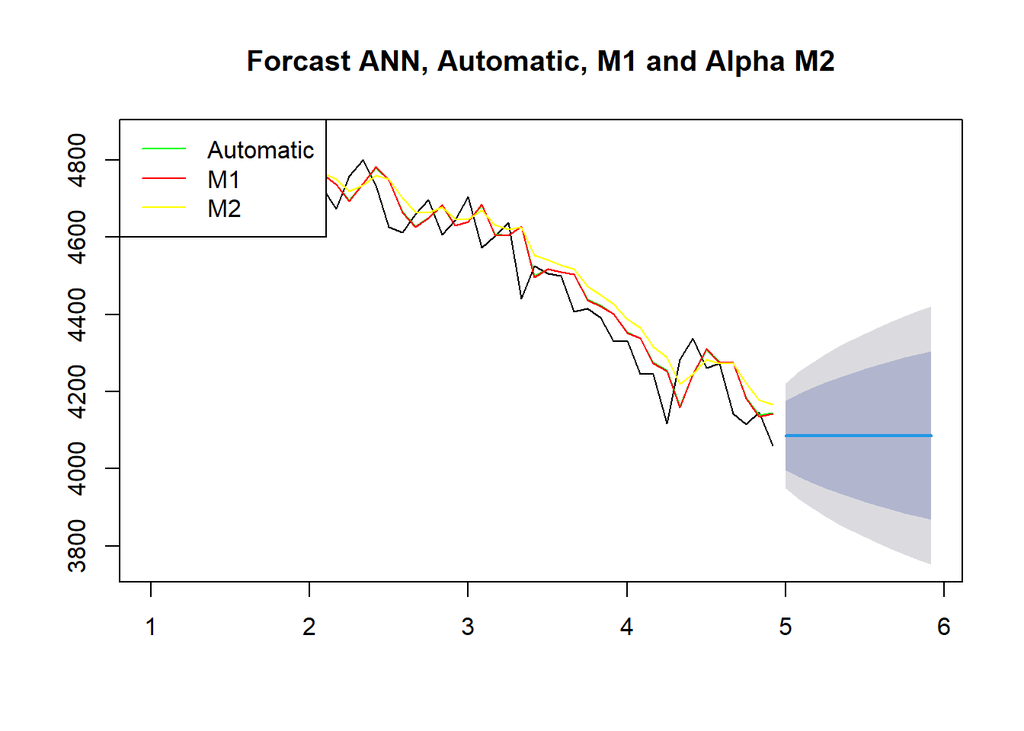

```r
plot(frc, main = "Forcast ANN, Automatic, M1 and Alpha M2")
lines(fit$fitted,col="green")
lines(fit_m1$fitted,col="red")
lines(fit_m2$fitted,col="yellow")
legend("topleft",c("Automatic","M1","M2"),col=c("green","red","yellow"),lty=1)
```